# Machine Learning for Human Learners

Intro: Key Concepts + Core Methods

Machine learning for human learners can initially seem a clash of two mutually unintelligible types of minds. The good news, as with many such meetings, is that it need not remain that way for long. Machine learning isn’t black magic, nor some inaccessible power locked under the semi-arcane runes of math. As we’ll present it to you here, it can instead be considered the algorithmic “stringing together” of a small set of more intuitive, even primordial actions — *draw a line through the dots*, *put similar things together*, *squash many measurements into a few* — that computers can repeatedly execute. Harness the ability to translate your intuitions into one of the various formulations that computers can repeat, and the power of machine learning is yours for the reclamation. In this tutorial, we’ll give you a brief intro to some of the key concepts, play around and quite literally poke at the underlying mechanics, and introduce you to some examples of basic code to start your journey towards the savvy deployment of your human learning over the workings of the machine.

**How to use this page.** Every figure with a play button or a slider is live: drag things, break things, and watch the readout underneath tell you what happened. The grey code blocks are real [scikit-learn](https://scikit-learn.org) code you can copy into your own analyses. Prefer to run it yourself? The [generated notebook opens in Google Colab](https://colab.research.google.com/github/ColinConwell/ML4HL-Workshop/blob/main/ML4HL-Tutorial.ipynb), including the interactive figures. [Download the source and notebook](https://github.com/ColinConwell/ML4HL-Workshop).

**Abbreviations Used in the Figures**

**GD** means gradient descent (taking downhill steps); **SGD** means stochastic gradient descent (estimating those steps from small, randomly selected batches). **OLS** means ordinary least squares (the line that minimizes squared misses). **MSE** means mean squared error (the average squared miss), and **RMSE** is its square root, which brings the error back to the outcome’s original units. **CV** means cross-validation (rotating which observations are held out). In classifier labels, **kNN** means *k*-nearest neighbors (a vote among nearby examples), **SVM** means support vector machine (a classifier that seeks separation between categories), and **RBF** means radial basis function (a smooth measure of how strongly nearby points influence the prediction).

**Regression**predict a number

**Categorization**predict a label

**Clustering**find groups nobody labeled

**Dimensionality reduction**represent data with fewer coordinates

**Representational similarity analysis (RSA)**compare two minds (or models)

**Cross-validation**evaluate held-out performance

**Setup: imports and the ml4hl helper**

```python
import sys
import os
N_JOBS = int(os.environ.get("ML4HL_N_JOBS", "2"))
N_THREADS = int(os.environ.get("ML4HL_THREADS", "2"))
for _thread_variable in ("OMP_NUM_THREADS", "OPENBLAS_NUM_THREADS", "MKL_NUM_THREADS"):
    os.environ[_thread_variable] = str(N_THREADS)

import ml4hl  # Installed locally, or bundled by the generated Colab setup.

from ml4hl import show

import numpy as np
import pandas as pd
import matplotlib.pyplot as plt
import seaborn as sns
from threadpoolctl import threadpool_limits

# Bound native-library threads too; n_jobs controls a separate layer of parallelism.
_thread_limit = threadpool_limits(limits=N_THREADS)

ml4hl.reset_assets()
ml4hl.set_style()
ml4hl.enable_theme_plots()
C = ml4hl.COLORS  # Named plotting colors, e.g. C["blue"].
rng = np.random.default_rng(2026)  # A fixed seed makes random examples reproducible.
```

# 1 What is machine learning?

## 1.1 A Machine Is a Recipe

A *machine*, for our purposes, is anything that turns an **input** into an **output** by following a fixed recipe. A thermostat turns a temperature into “heat on” or “heat off”. A spreadsheet formula turns a column of numbers into their average. Your microwave turns “2 minutes, high” into a hot burrito. None of these machines *learn*: give them the same input tomorrow and they will do exactly the same thing.

## 1.2 Learning Is Changing the Recipe

*Learning* means the recipe improves with experience. Show a learning machine a few hundred examples of inputs paired with the outputs you wanted, and it adjusts its internal parameters (the *weights*, or knobs) until its outputs match yours more closely. The real test is whether that tuned recipe can *generalize* (produce comparably desirable outputs) to inputs it has **never seen**.

Memorizing examples can be part of a learning algorithm, but the practical question is whether that memorization comes at the cost of learning patterns that generalize *across* examples — a key requirement of accurate prediction on as-of-yet unseen (new) data. The execution of a fixed formula whose behavior never changes with experience (e.g. the arithmetic done by a calculator) is not an instance of machine learning.

**Takeaway #1**

Learning uses past data (previous experience) to construct and update models that predict unseen data (future experiences).

## 1.3 Landscapes of Loss (and Gain)

How does a machine know which way to turn its knobs? It evaluates an **error** (or **loss**): usually, a single number measuring how far apart the machine’s current outputs (predictions) are from the target outputs (ground-truth). Plotting error across every possible knob setting forms a landscape of hills and valleys. Gradient-based training (the method that drives effectively all modern deep learning algorithms) takes steps intended to reduce the objective; it can converge to a local solution or fail to converge at all.

The standard descent algorithm, **gradient descent**, uses only local information: measure the slope of the error surface at the current position, take a step in the steepest downhill direction, and repeat. The size of that step is the **learning rate**. Press play below, try a larger step size, and drag the ball to different starting points to see this process in action.

**Show the interactive figure code**

```python
show("error_landscape")
```

Toggle **hide unvisited landscape** to reveal only the places the ball has explored and a small neighborhood around them. In real-world machine learning, this cartography is usually uncharted: we can calculate loss and slope at the settings we try, but cannot inspect every possible setting in advance.

With a tiny step size, the ball settles into the first valley it encounters and stays there, even when a deeper basin sits just across the ridge. That shallow valley is a **local minimum**; the lowest point on the entire surface is the **global minimum**. Larger steps can carry the ball across small ridges, while steps that are too large overshoot the valley walls and oscillate without converging.

**Takeaway #2**

Many learning methods optimize an objective, but with incomplete information they need not find its global minimum. Even that minimum need not be the pattern that best predicts data not yet seen.

Not all methods we’ll discuss in this tutorial use gradient-based optimization as part of their learning: some use analytical methods (exact calculations) that minimize a specified loss in one solve; others repeatedly regroup observations or retain examples for later comparison. Resampling helps us explore how results might change with different data, without revealing the true loss on data we have not seen. We begin with this schematic because the success or failure of a method depends on what we ask it to optimize and how we evaluate the result. It is you, the human learner, who chooses those coordinates: the target, the evidence, and the scope of generalization. A machine can search that properly specified space in ways no human can, but it cannot decide by itself which scientific question is worth asking.

## 1.4 Research Domains in This Tutorial

Each method section moves from interactive simulation to working Python code on open research datasets drawn from five fields:

#### Anthropology: household surveys & media

World Bank Living Standards Measurement Study (LSMS) household health and expenditure surveys; Gapminder Dollar Street home photographs and image embeddings.

#### Developmental & clinical psychology

Stanford Wordbank Communicative Development Inventories (CDI) infant vocabulary curves (8–30 months); Infant Health and Development Program (IHDP) perinatal risk, child reading, language, and attention; 42-item Depression Anxiety Stress Scales (DASS-42).

#### Music therapy & vocal communication

The Music Lab cross-cultural lullabies, healing songs, and infant-directed vocalizations across 21 societies; Cowen et al. 13-dimensional music emotion ratings.

#### Organismal & perceptual biology

Zebra finch vocal repertoires and spectrograms (Elie & Theunissen); THINGS human odd-one-out similarity judgments.

#### Clinical medicine

Fine-needle breast biopsy cytomorphology and PneumoniaMNIST pediatric chest X-rays.

# 2 Regression: Predicting Points with Lines

Regression predicts a continuous quantity from one or more measurements: a household’s total expenditure from health and demographic indicators, a child’s reading score from perinatal risk factors, or productive vocabulary size from age in months. In linear regression, the knobs set the slope and intercept of a straight line (or a flat hyperplane across many predictors: a line extended to a plane in three dimensions, then to more dimensions), and the error is the sum of squared vertical distances between the line and the observed points.

## 2.1 Regression by Eye + OLS (Ordinary Least Squares)

Drag the two round handles (or grab the line itself) until the fit looks right. Each residual square shows a **residual** — the vertical miss for one observation — drawn as a literal square proportional to the residual in screen coordinates. The meter in the corner sums the areas of all those squares.

**Show the interactive figure code**

```python
show("ols_fit")
```

Click **show best line** to compare your eye fit against the analytic optimum, or **snap to least squares** to animate your line to the minimum-error solution. Because **ordinary least squares (OLS)** minimizes the sum of *squared* residuals, a residual twice as large contributes four times as much area, making large residuals costly. Leverage specifically concerns extreme predictor values, which can make observations influential when combined with their residuals.

## 2.2 Regression by Gradient Descent

A straight line has a closed-form algebraic solution, but most machine learning models do not. To bridge the two worlds, we can fit the exact same line by gradient descent. Because a line has two knobs (slope and intercept), the error landscape is a two-dimensional bowl: darker contours mark lower error, and the gold star marks the least-squares minimum.

**Show the interactive figure code**

```python
show("gd_regression")
```

Click anywhere on the contour map to initialize a new starting line, then press play. A moderate learning rate tracks smoothly down the valley floor to the star; an overly large learning rate zig-zags across the canyon walls or diverges.

**Takeaway #3**

A model is a parameterized family of functions. Training adjusts the parameters to minimize error.

## 2.3 Non-Linear Regression: Bending the Line with Splines

Relationships in biological and developmental data are often nonlinear. Average vocabulary production changes with age, while children differ substantially at each age. The position and shape of any apparent acceleration depend on the population and measurement instrument. Dose-response curves may saturate, and acoustic signals can oscillate.

One way to bend the line is to use a **polynomial**, adding terms that let the whole line curve and wiggle. Like the flexible fits above, extra bends can bring it closer to the dots we have seen. But pulling it toward one dot can also send another part swinging away, especially near the ends or beyond the observed data.

A **spline** bends the line in smaller, connected pieces. Choose a few places along the input axis where the line can change direction — called **knots**, like joints in a folding ruler — and fit the pieces together. More adjustable pieces give the model more **degrees of freedom**: more independent ways to change its shape to fit the observations.

- A **piecewise-linear spline** connects the joints with straight segments.
- A **cubic spline** rounds those joins into smooth bends.

The issue with non-linearities like splines is the possibility of over-fitting: every non-linearity we add allows our line to bend in ways that can progressively reduce its distance to our data points. Give the curve enough independently adjustable pieces and it can pass through every distinct input point: a version of memorization — and (usually) a classic case of “over-fitting”. Too many curves and our line may well cover the data we’ve seen, but add new data (even data that’s close to the data we’ve fit) and the coverage can quickly become worse than a line with no curves at all. Repeated inputs with different outcomes cannot all be fit exactly; constraints that discourage unnecessary bending also limit this flexibility.

**Show the interactive figure code**

```python
show("spline_scaling")
```

Press play, or move the segment-count slider, in Figure 4 above. On the left, additional pieces let the fitted line follow the target curve more closely; on the right, the falling error shows how much those extra pieces improve the match. With real vocabulary data, compare that increasingly flexible line with the spread of children at each age. Following the observations more closely does not by itself show that the curve will predict a new child more accurately.

### 2.3.1 From Splines to Neural Networks: Rectified Linear Unit (ReLU) Hinges

A **rectified linear unit (ReLU)** acts like a hinge: it stays flat until its input crosses a threshold, then rises as a straight line, so combining hinges can create bends much like a spline. ReLUs are a key component of deep neural networks, letting models learn non-linear relationships — such as how combinations of shapes indicate an object’s category — while navigating much more complex loss landscapes.

Drag the hinges below, or press **optimize knots (GD)** to let gradient descent adjust them (GD is the control’s abbreviation).

**Show the interactive figure code**

```python
show("spline_relu_basis")
```

**Takeaway #4**

Spline regression combines basis functions to model curvature. A one-dimensional ReLU network represents a continuous piecewise-linear function whose breakpoints can be learned.

**Measurement and interpretation**

The perinatal stress index is a teaching composite constructed from neonatal health, gestation, birthweight, smoking, prenatal care, and maternal education, with manually chosen weights and full-sample scaling. It is not a validated maternal-stress measure. The externalizing score is not a specific attention scale. These observational examples do not identify causal effects. Predictive models below use the original covariates rather than the full-sample composite.

## 2.4 Your Data in the Widgets

Widgets with a documented data mode accept a `data=` dictionary so you can inspect your own variables in the same interactive view. Below, we pass two developmental datasets straight into the regression and spline widgets:

1. **Perinatal stress and child reading achievement** (`load_perinatal_dev`, from the longitudinal Infant Health and Development Program cohort, $n = 837$), plotting a composite perinatal stress and adversity index against Woodcock-Johnson broad reading scores at age 8.
2. **Early vocabulary growth** (`load_wordbank`, from Stanford Wordbank MacArthur-Bates CDI parent reports across $7,955$ American English toddlers aged 8 to 30 months).

**Show the interactive figure code**

```python
from ml4hl.samples import perinatal_reading, wordbank_vocab

show("gd_regression", data=perinatal_reading(n=150))
```

**Show the interactive figure code**

```python
show("spline_scaling", data=wordbank_vocab(n=180), degree="cubic")
```

## 2.5 Quick Start: Linear & Spline Regression in Scikit-learn

Supervised `scikit-learn` estimators share a common workflow: instantiate the model, call `.fit(X_train, y_train)` to estimate parameters on training data, and call `.score(X_test, y_test)` or `.predict(X_test)` on held-out test data. Transformers and unsupervised estimators expose interfaces appropriate to their tasks.

First, let’s fit a linear regression on **World Bank Living Standards Measurement Study (LSMS)** household survey data (`load_household_survey`, $5,006$ households across $194$ communes), predicting log total household expenditure from $10$ demographic, educational, agricultural, expenditure, and commune-level health indicators. We hold out entire communes. Medical spending is a component of household spending, so this example measures contemporaneous association rather than forecasting future expenditure. Commune summaries also require population-level information at prediction time:

**Variables in This Example**

`household_features` holds the ten measured predictors (one row per household). `household_expenditure` is log total expenditure, the outcome to predict. `training_rows` and `test_rows` select households in separate communes.

```python
from sklearn.linear_model import LinearRegression
from sklearn.model_selection import train_test_split, GroupShuffleSplit
from ml4hl.data import load_household_survey

survey = load_household_survey()
survey_features = [
    "educ_years", "urban", "farm", "hhsize", "head_age", "head_female",
    "log_med_exp", "commune_illness_rate", "commune_insurance_rate", "commune_pharmacy_visits",
]
# Rows are households; columns are the measured predictors listed above.
household_features = survey[survey_features]
household_expenditure = survey["log_total_exp"]
```

Next, hold out entire communes so that the test households come from places the model has not seen. The remaining households supply the training examples.

```python
# Split by commune so neighboring households cannot appear on both sides.
training_rows, test_rows = next(GroupShuffleSplit(n_splits=1, test_size=0.25, random_state=0).split(household_features, groups=survey["commune"]))
training_features, test_features = household_features.iloc[training_rows], household_features.iloc[test_rows]
training_outcomes, test_outcomes = household_expenditure.iloc[training_rows], household_expenditure.iloc[test_rows]
assert set(survey.commune.iloc[training_rows]).isdisjoint(survey.commune.iloc[test_rows])
```

Now fit the line using the training households and score its predictions on the held-out households. R² compares squared prediction errors with a baseline that always predicts the test-set mean; 1 is perfect, 0 matches that baseline, and negative values are worse.

```python
model = LinearRegression()            # Create the model: its coefficients will be learned from the training examples.
model.fit(training_features, training_outcomes)           # Learn coefficients using only training households.
r2 = model.score(test_features, test_outcomes)      # Evaluate predictions for households excluded from fitting.
print(f"R² on {len(test_outcomes):,} held-out households: {r2:.2f}")
```

```
R² on 1,258 held-out households: 0.51
```

Compare predicted and observed spending, then inspect each coefficient after expressing its predictor change in standard-deviation units. These coefficients describe association within this fitted model.

```python
predicted_expenditure = model.predict(test_features)
# Scale each coefficient by one standard deviation of its training predictor.
standardized_coefficients = pd.Series(model.coef_ * training_features.std().to_numpy(), index=household_features.columns).sort_values()
```

**Show the figure code**

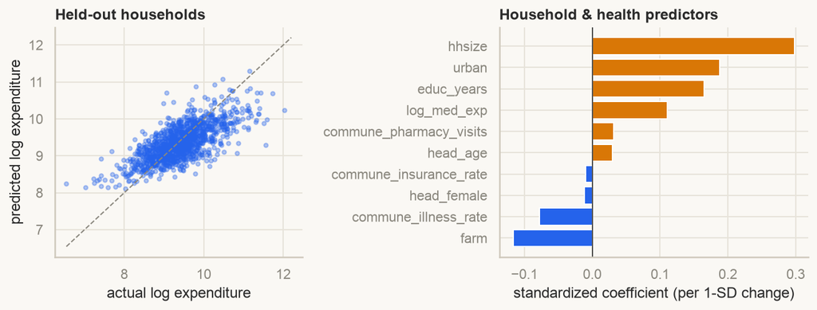

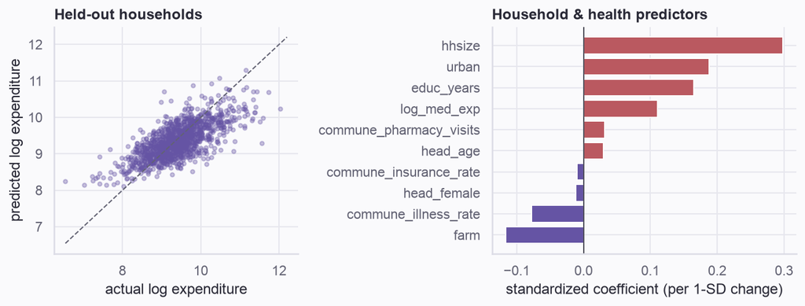

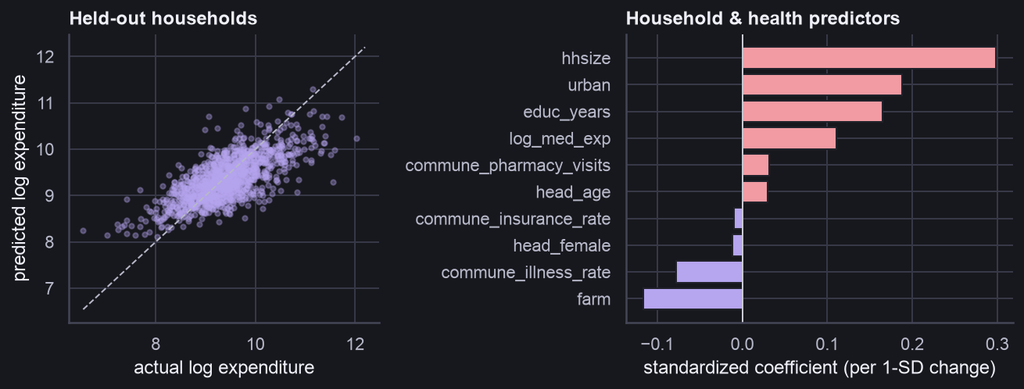

```python
# Draw the results computed above; this cell does not fit the model.
fig, axes = plt.subplots(1, 2, figsize=(9.2, 3.6), gridspec_kw={"width_ratios": [1, 1.25]})

axes[0].scatter(test_outcomes, predicted_expenditure, s=10, color=C["blue"], alpha=0.35)
lims = [household_expenditure.min(), household_expenditure.max()]
axes[0].plot(lims, lims, ls="--", color=C["muted"], lw=1)
axes[0].set(xlabel="actual log expenditure", ylabel="predicted log expenditure", title="Held-out households")

axes[1].barh(standardized_coefficients.index, standardized_coefficients.values,
             color=[C["orange"] if v > 0 else C["blue"] for v in standardized_coefficients])
axes[1].axvline(0, color=C["ink"], lw=0.8)
axes[1].set(xlabel="standardized coefficient (per 1-SD change)", title="Household & health predictors")
plt.tight_layout()
```

Now compare a straight line against `SplineTransformer` on the **Wordbank CDI child vocabulary** trajectory. In `scikit-learn`, `SplineTransformer` turns age into several linked features that let a line bend (`degree=1` uses straight pieces; `degree=3` uses smooth curves). A pipeline connects those features to `RidgeCV`, a regression method that discourages overly large weights and chooses that constraint through cross-validation:

**Variables in This Example**

`child_age_months` is the continuous predictor, measured in months. `vocabulary_scaled` is the checklist production share multiplied by 680; it is a rescaled score, not a directly comparable word count across checklist forms.

```python
from sklearn.preprocessing import SplineTransformer
from sklearn.linear_model import RidgeCV
from sklearn.pipeline import make_pipeline
from ml4hl.data import load_wordbank

wordbank = load_wordbank("English (American)")
# Double brackets retain the two-dimensional feature table scikit-learn expects.
child_age_months = wordbank[["age"]].to_numpy(dtype=float)
# Put checklist shares on a common numeric scale; this is not a raw word count.
vocabulary_scaled = (wordbank["vocab_share"] * 680.0).to_numpy(dtype=float)
```

Next, reserve one quarter of the assessments to compare predictions on observations excluded from fitting. This illustrative split is by assessment; developmental inference would require child-level grouping.

```python
training_ages, test_ages, training_vocabulary, test_vocabulary = train_test_split(child_age_months, vocabulary_scaled, test_size=0.25, random_state=0)
```

Define three models with increasing freedom to bend. `RidgeCV` chooses how strongly to discourage large coefficients using internal cross-validation, helping control unnecessary flexibility.

```python
# Each pipeline fits its feature transformation using training data only.
spline_models = {
    "straight line (OLS)": LinearRegression(),
    "piecewise-linear spline (degree=1, 6 knots)": make_pipeline(
        SplineTransformer(n_knots=6, degree=1), RidgeCV()
    ),
    "cubic B-spline (degree=3, 6 knots)": make_pipeline(
        SplineTransformer(n_knots=6, degree=3), RidgeCV()
    ),
}
```

Fit each model on the same training observations, then report R² on the same held-out assessments. Compare those scores before interpreting the curves.

```python
spline_scores = {}
for name, estimator in spline_models.items():
    estimator.fit(training_ages, training_vocabulary)
    spline_scores[name] = estimator.score(test_ages, test_vocabulary)
    print(f"{name}: held-out R² = {spline_scores[name]:.3f} across {len(test_ages):,} vocabulary assessments.")

# Prepare evenly spaced ages for drawing the fitted curves.
age_grid = np.linspace(8, 30, 200)[:, None]
curve_predictions = {name: estimator.predict(age_grid) for name, estimator in spline_models.items()}
monthly_vocabulary_means = wordbank.groupby("age")["vocab_share"].mean() * 680.0
```

```
straight line (OLS): held-out R² = 0.617 across 1,989 vocabulary assessments.
piecewise-linear spline (degree=1, 6 knots): held-out R² = 0.640 across 1,989 vocabulary assessments.
cubic B-spline (degree=3, 6 knots): held-out R² = 0.641 across 1,989 vocabulary assessments.
```

**Show the figure code**

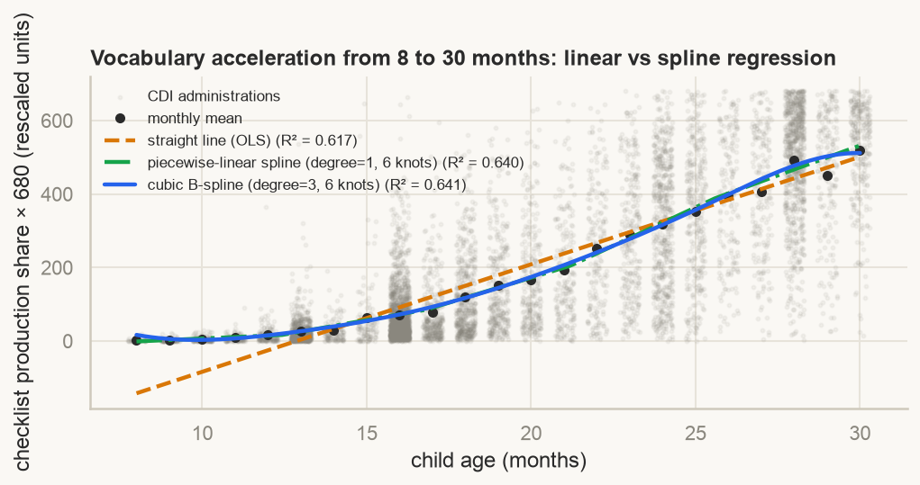

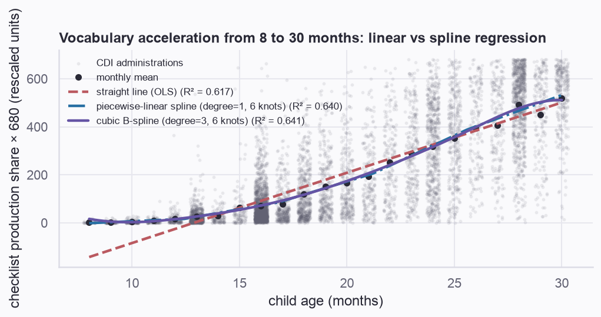

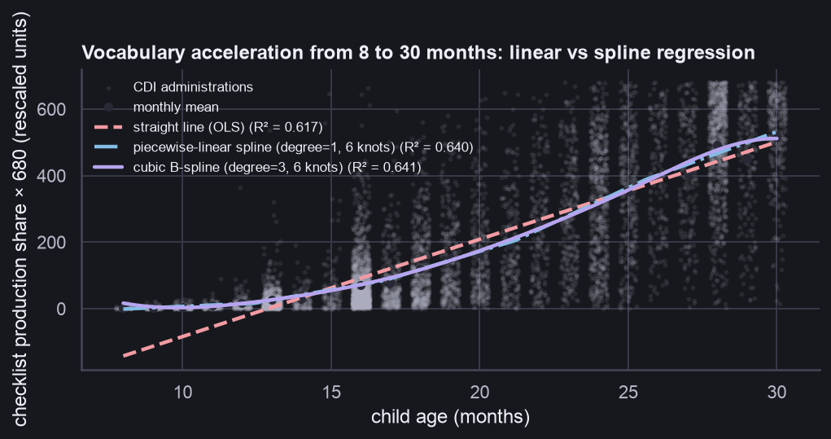

```python
# Draw the results computed above; this cell does not fit the model.
fig, ax = plt.subplots(figsize=(7.2, 3.6))
ax.scatter(wordbank["age"] + rng.uniform(-0.3, 0.3, len(wordbank)), vocabulary_scaled, s=4, alpha=0.08, color=C["muted"], label="CDI administrations")
ax.plot(monthly_vocabulary_means.index, monthly_vocabulary_means.values, "o", color=C["ink"], ms=4.5, label="monthly mean")

for (label, estimator), col, ls in zip(spline_models.items(), [C["orange"], C["green"], C["blue"]], ["--", "-.", "-"]):
    r2_val = spline_scores[label]
    ax.plot(age_grid[:, 0], curve_predictions[label], color=col, ls=ls, lw=2.2, label=f"{label} (R² = {r2_val:.3f})")

ax.set(xlabel="child age (months)", ylabel="checklist production share × 680 (rescaled units)",
       title="Vocabulary acceleration from 8 to 30 months: linear vs spline regression")
ax.legend(frameon=False, fontsize=8.5, loc="upper left")
plt.tight_layout()
```

Compare the fitted curves and held-out scores above. The two CDI forms have different checklists: multiplying checklist share by 680 creates a common numerical scale, not a validated conversion to a common vocabulary count. Overlapping ages, form composition, and repeated administrations can influence this illustration; use instrument-aware analyses and child-level splits for developmental inference.

## 2.6 Applied Examples

**Anthropology: Dollar Street Home Photos**

[Dollar Street](https://www.gapminder.org/dollar-street) is a documentary photography project in which field photographers visited hundreds of households across dozens of countries and photographed standardized everyday items (the front door, the bed, the stove, the toothbrush) alongside each household’s monthly purchasing-power-adjusted income.

To run regression on photographs, we first pass each image through a pretrained vision-language backbone (here [SigLIP 2](https://huggingface.co/google/siglip2-base-patch16-224), Sigmoid Loss for Language Image Pre-training), which maps each image to a 768-dimensional embedding vector where visually and semantically related scenes lie nearby. We then fit regularized linear regression (`RidgeCV`) from those 768 features to log monthly income.

**Variables in This Example**

`photo_metadata` describes each photograph and its household. `photo_embeddings` contains 768 learned image features per photograph; `photo_thumbnails` holds small images for display. `log_income` is the base-10 logarithm of monthly income.

```python
from ml4hl.data import load_dollar_street

dollar_street = load_dollar_street()
photo_metadata, photo_embeddings, photo_thumbnails = dollar_street["meta"], dollar_street["emb"].astype(float), dollar_street["thumbs"]
print(f"{len(photo_metadata)} photos from {photo_metadata.place.nunique()} households in {photo_metadata.country.nunique()} countries")
print(f"monthly income: ${photo_metadata.income.min():.0f} to ${photo_metadata.income.max():,.0f} (purchasing-power-parity dollars)")
photo_metadata.head()
```

```
1041 photos from 297 households in 57 countries
monthly income: $64 to $19,671 (purchasing-power-parity dollars)
```

|  | id | topic | country | region | place | income |
| --- | --- | --- | --- | --- | --- | --- |
| 0 | 5d4bea0fcf0b3a0f3f349b82 | home | India | as | mondal | 135.010277 |
| 1 | 5ec4f804f0611d7ddd740b33 | home | Nepal | as | khatbe | 136.000000 |
| 2 | 5ec4f806f0611d7ddd740b3e | home | Nepal | as | khatbe | 136.000000 |
| 3 | 5d4be3facf0b3a0f3f33f474 | home | Cameroon | af | moamoasse | 137.000000 |
| 4 | 5d4be73ecf0b3a0f3f34519c | home | Myanmar | as | wai | 141.000000 |

**Show the figure code**

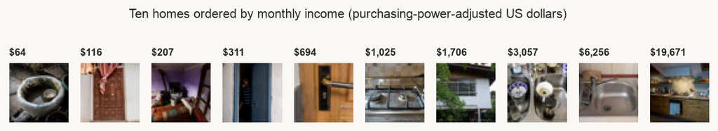

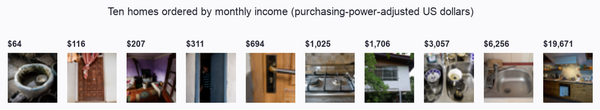

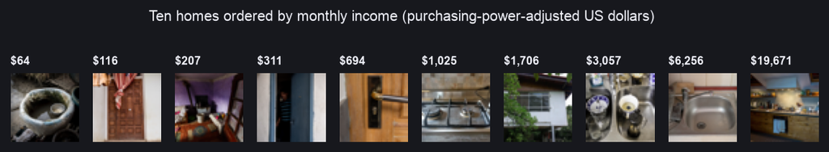

```python
# Select and label observations for this figure.
order = photo_metadata.sort_values("income").index.to_numpy()
picks = order[np.linspace(0, len(order) - 1, 10).astype(int)]
fig, axes = plt.subplots(1, 10, figsize=(10, 1.6))
for ax, i in zip(axes, picks):
    ax.imshow(photo_thumbnails[i]); ax.set_axis_off()
    ax.set_title(f"${photo_metadata.income[i]:,.0f}", fontsize=8)
fig.suptitle("Ten homes ordered by monthly income (purchasing-power-adjusted US dollars)", y=1.08, fontsize=10)
plt.show()
```

Because each household contributes multiple photographs (bed, stove, front door), random train/test splits would place different rooms from the same home on both sides of the split. We use `GroupKFold` grouped by household (`photo_metadata.place`) so every test prediction is made on an unseen home.

```python
from sklearn.model_selection import GroupKFold, cross_val_predict
from sklearn.metrics import r2_score

# A log scale compares proportional income differences rather than raw dollars.
log_income = np.log10(photo_metadata.income)
ridge = RidgeCV(alphas=np.logspace(-2, 3, 12))
# Every prediction comes from a fold that excluded this household.
predicted_log_income = cross_val_predict(ridge, photo_embeddings, log_income, groups=photo_metadata.place, cv=GroupKFold(5, shuffle=True, random_state=0))
print(f"R² on unseen households: {r2_score(log_income, predicted_log_income):.2f}")
```

```
R² on unseen households: 0.65
```

**Show the figure code**

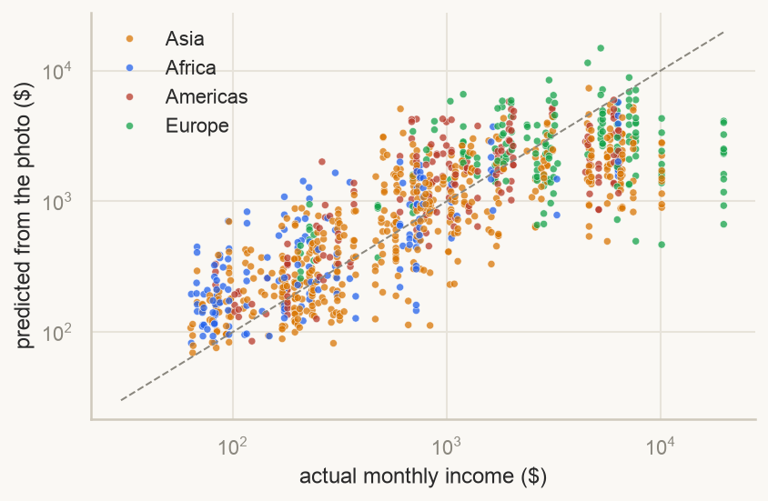

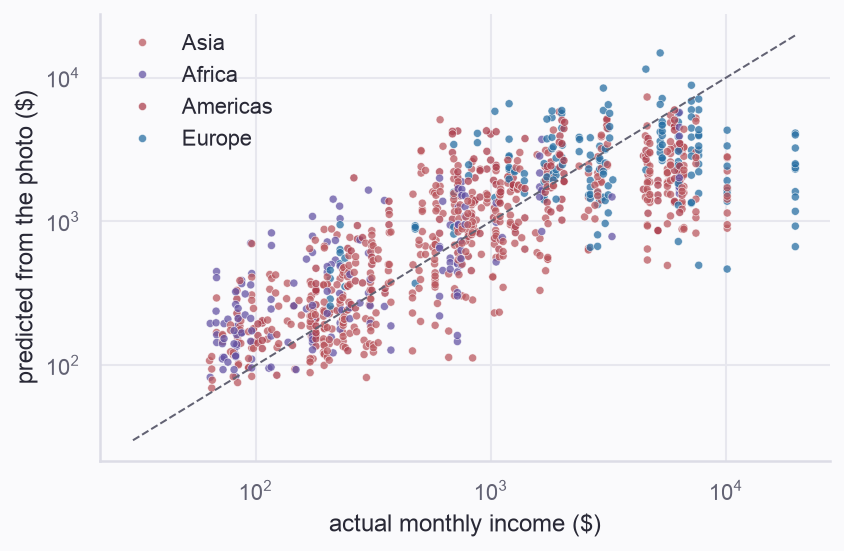

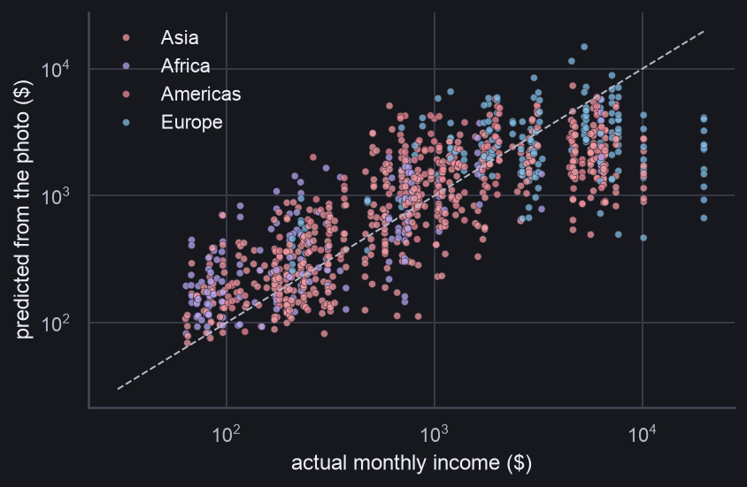

```python
# Select and label observations for this figure.
region_names = {"af": "Africa", "am": "Americas", "as": "Asia", "eu": "Europe"}
fig, ax = plt.subplots(figsize=(6.5, 4))
sns.scatterplot(x=10 ** log_income, y=10 ** predicted_log_income, hue=photo_metadata.region.map(region_names), s=16, alpha=0.75,
                palette=[C[c] for c in ["orange", "blue", "red", "green"]], ax=ax)
ax.set(xscale="log", yscale="log", xlabel="actual monthly income ($)", ylabel="predicted from the photo ($)")
ax.plot([30, 20000], [30, 20000], ls="--", color=C["muted"], lw=1)
ax.legend(title=None, frameon=False)
plt.show()
```

**Confounders and shortcut learning: what is the model actually measuring?**

When a high-dimensional model predicts a social or clinical outcome with high accuracy, inspect what cues drive the prediction. In household photographs, a vision backbone encodes construction materials and appliances, but also lighting, lens focal length, sensor noise, and regional vegetation. In fieldwork and clinical deployment, reliance on these correlated background cues (**shortcut learning**) can cause a model to fail when camera equipment or setting changes, or to reproduce regional and socioeconomic proxies that were never the scientific target.

**Psychology: Perinatal Risk, Language & Reading**

In developmental psychopathology, researchers track how prenatal and neonatal risk factors relate to later language, reading, and attentional outcomes. Using the longitudinal IHDP cohort (`load_perinatal_dev`, $837$ children followed from birth to age 8 across $8$ clinical sites), we can compare linear and spline models predicting age-8 receptive vocabulary (`vocab_96m`, Peabody Picture Vocabulary Test–Revised, or PPVT-R) and reading achievement (`reading_96m`, Woodcock-Johnson) from perinatal risk, birthweight, gestational age, maternal education, and early intervention status. The supplied table includes an upstream imputed maternal Peabody Picture Vocabulary Test (PPVT) variable and complete-case outcome selection. We cannot reconstruct that upstream imputation inside each fold, so these illustrative scores are conditional on the released preprocessing and should not be treated as a fully leakage-audited clinical estimate:

**Variables in This Example**

`perinatal_features` contains the named birth, family, and intervention measurements. Each `target_col` selects one age-8 outcome. `site_cv` keeps children from the same clinical site together.

```python
from ml4hl.data import load_perinatal_dev
from sklearn.preprocessing import StandardScaler
from sklearn.model_selection import cross_val_score

perinatal = load_perinatal_dev()
perinatal_predictors = [
    "prenatal_cigs_per_day", "prenatal_care_trimester", "birthweight_g", "gestational_age_wk",
    "neonatal_health", "maternal_age", "maternal_ed_level", "maternal_vocab_ppvt", "intervention",
]
# Keep the original measured covariates instead of the teaching stress composite.
perinatal_features = perinatal[perinatal_predictors]
site_cv = GroupKFold(5)
```

Compare straight and curved models for each outcome, always holding out whole clinical sites. Scaling and spline construction are fitted inside each training fold through a pipeline.

```python
for target_col, label in [("reading_96m", "Age-8 reading (Woodcock-Johnson)"),
                          ("vocab_96m", "Age-8 receptive language (PPVT-R)"),
                          ("externalizing_96m", "Age-8 externalizing (Child Behavior Checklist)")]:
    linear_pipeline = make_pipeline(StandardScaler(), RidgeCV(alphas=np.logspace(-1, 3, 9)))
    spline_pipeline = make_pipeline(StandardScaler(), SplineTransformer(n_knots=4, degree=2), RidgeCV(alphas=np.logspace(0, 4, 9)))
    linear_score = cross_val_score(linear_pipeline, perinatal_features, perinatal[target_col], groups=perinatal["site"], cv=site_cv).mean()
    spline_score = cross_val_score(spline_pipeline, perinatal_features, perinatal[target_col], groups=perinatal["site"], cv=site_cv).mean()
    print(f"{label:<42} | Linear R² = {linear_score:.2f} | Spline R² = {spline_score:.2f}")
```

```
Age-8 reading (Woodcock-Johnson)           | Linear R² = 0.21 | Spline R² = 0.21
Age-8 receptive language (PPVT-R)          | Linear R² = 0.28 | Spline R² = 0.29
Age-8 externalizing (Child Behavior Checklist) | Linear R² = 0.01 | Spline R² = -0.00
```

**Going faster**

`scikit-learn` estimators run on the central processing unit (CPU) by default. Two drop-in extensions accelerate the same application programming interface (API: the methods you call), for supported estimators:

- **NVIDIA cuML**: on a Colab graphics processing unit (GPU) runtime, load `%load_ext cuml.accel` at the top of the notebook to dispatch `Ridge`, `KMeans`, `PCA` (principal component analysis), and `UMAP` (uniform manifold approximation and projection) to the GPU.
- **Intel Extension for scikit-learn**: `pip install scikit-learn-intelex`, then call `from sklearnex import patch_sklearn; patch_sklearn()` before importing `scikit-learn` estimators.

# 3 Categorization: Predict a Label

Where regression predicts a continuous number, **classification** predicts a discrete *category*: benign or malignant biopsy, infant-directed lullaby or adult dance song, begging call or distance call. Different classifiers use different fitting procedures; their predictions define a **decision boundary** that partitions feature space into class territories.

## 3.1 What Categories Look Like to a Machine

Each observation is a point with one coordinate per feature (its position along each measurement axis in an $x, y, z, \ldots$ space). A category forms a cloud or **manifold** of points in that space. Some manifolds form well-separated clusters that a single flat hyperplane (the higher-dimensional extension of a line or plane) can split; others form interlocking crescents, concentric rings, or alternating quadrants where any straight line fails.

**Show the interactive figure code**

```python
show("category_manifolds")
```

Switch across the five geometries above and watch the dashed line, which shows a regularized multinomial logistic classifier (the next method we’ll learn) fitted by gradient descent to the current cloud. Read its training accuracy as you change the geometry; a straight boundary cannot represent concentric rings. Click anywhere on the canvas to add points (shift-click for the next category) and watch the linear boundary re-fit.

**Takeaway #5**

A classifier learns the boundaries of categorical groupings based on a set of features that differentiate the exemplars of those categories to greater or lesser extents.

## 3.2 Logistic Regression: A Boundary with Probability Estimates

**Logistic regression** first gives each feature a weight and adds up its contribution, much as linear regression combines measurements to predict a number. It then passes that total through an S-shaped curve, the **logistic sigmoid**, that squeezes any score into a probability between $0$ and $1$. Points far from the boundary receive probabilities near $0$ or $1$ depending on the class; points along the boundary receive $0.50$. Its loss, **cross-entropy** (also called log loss), measures how poorly those probabilities match the observed labels: a confident wrong answer costs much more than an uncertain one. Training moves downhill on this loss landscape by changing the feature weights.

**Show the interactive figure code**

```python
show("logistic_gd")
```

Press play to watch the probability field sharpen from uniform uncertainty ($0.50$ everywhere) into two territories. The solid line marks the $50\%$ boundary, the thin dashed lines mark the $25\%$ and $75\%$ contours, and the reference dashed line marks a reference solution found by a numerical solver for the same loss; it uses the local slope and curvature to take more directed steps toward a minimum. Probability estimates are not automatically calibrated on new populations. Increase the class overlap slider to see how the probability gradient widens when the two distributions interpenetrate.

## 3.3 Deep-Cut Sneak Peek: The Linear Perceptron

In 1958 Frank Rosenblatt introduced the **perceptron**, a single artificial neuron that computes a weighted sum of its inputs and outputs $1$ when the sum crosses a threshold:

**Show the interactive figure code**

```python
show("perceptron")
```

The left panel displays the network weights (separate colors distinguish positive and negative weights; line width indicates magnitude); the right panel displays the corresponding linear boundary in the input plane. Whenever the perceptron misclassifies a point, its update rule changes the weights in a direction that reduces that misclassification. Press play on the **separable** preset to watch the boundary converge, then switch to **XOR** to see why a single linear unit cycles indefinitely — a limitation that a suitable hidden layer of non-linear units can overcome.

**XOR (exclusive OR)** labels two inputs as positive when exactly one is on, and negative when both are on or both are off. The matching labels sit in opposite corners of a square, so no single straight line can separate the two classes.

## 3.4 One Dataset, Five Classifiers

Different classifier families carve feature space with different geometric primitives. Below, five `scikit-learn` estimators are fit across five settings of their primary complexity parameter on two datasets: simulated interlocking moons and cross-cultural songs from **The Music Lab’s Natural History of Song Discography** (`load_musiclab("nhs")`, separating lullabies, healing songs, and dance songs across $86$ societies by perceived tempo/beat and melodic pleasantness).

```python
from sklearn.datasets import make_moons
from ml4hl.data import load_musiclab
from ml4hl.zoo import decision_grids

song_records = load_musiclab("nhs")
selected_songs = song_records[song_records["type"].isin(["Lullaby", "Dance", "Healing"])].reset_index(drop=True)
X_moons, y_moons = make_moons(240, noise=0.3, random_state=0)
```

Fit the five classifier families to both datasets and prepare their predicted regions. The widget displays these Python-computed predictions as you change model complexity.

```python
zoo = [
    decision_grids(X_moons, y_moons, name="moons (simulated)", class_names=["A", "B"]),
    decision_grids(
        selected_songs[["form_fast", "form_melo"]].to_numpy(dtype=float),
        selected_songs["type"].to_numpy(),
        name="Music Lab songs",
        xlabel="perceived tempo / beat",
        ylabel="melodic pleasantness",
    ),
]
```

**Show the interactive figure code**

```python
show("classifier_zoo", data=zoo)
```

Slide each model from stiff to flexible and compare its training and held-out scores. More flexibility can improve training fit while worsening generalization, but monotonic changes and an intermediate test optimum are not guaranteed for every algorithm or sample. Repeatedly choosing settings from the displayed test scores turns that split into a validation set; a final performance estimate needs separate data.

| Model | Boundary geometry | Complexity parameter | `scikit-learn` estimator |
| --- | --- | --- | --- |
| Logistic regression | flat hyperplane | `C` (inverse $L_2$ penalty) | `LogisticRegression` |
| $k$-nearest neighbors | local majority vote | `n_neighbors` ($k$) | `KNeighborsClassifier` |
| Support vector machine | smooth radial kernels | `gamma` (kernel bandwidth) | `SVC` |
| Decision tree | axis-aligned rectangles | `max_depth` | `DecisionTreeClassifier` |
| Gradient boosting | additive ensemble of shallow trees | `max_iter` (boosting rounds) | `HistGradientBoostingClassifier` |

## 3.5 Applied Examples

**Music & Child Development: Cross-Cultural Vocalizations**

Across human societies, caregivers alter their voice when singing a lullaby to soothe an infant versus singing an adult song or speaking ([Mehr et al., 2019](https://doi.org/10.1126/science.aax0868); [Hilton et al., 2022](https://doi.org/10.1038/s41562-022-01410-x)). Using The Music Lab’s cross-cultural corpus (`load_musiclab("ids")`, $1,608$ recordings across $21$ societies), can a classifier distinguish vocalization contexts in **societies it has never heard**?

**Variables in This Example**

`acoustic_features` contains sound measurements for each recording. `within_vocalist_features` subtracts each person’s typical values. The targets are `song` (song versus speech) and `category` (four vocalization contexts).

```python
from sklearn.linear_model import LogisticRegression
from sklearn.ensemble import HistGradientBoostingClassifier
from sklearn.pipeline import make_pipeline
from sklearn.preprocessing import StandardScaler
from sklearn.model_selection import GroupKFold, StratifiedKFold, cross_val_score, cross_val_predict
from sklearn.metrics import ConfusionMatrixDisplay, classification_report

vocalizations = load_musiclab("ids")
# Select columns produced by the acoustic measurement tools.
acoustic_columns = [c for c in vocalizations.columns if c.startswith(("praat_", "mir_", "npvi_"))]
acoustic_features = vocalizations[acoustic_columns].to_numpy(dtype=float)
```

Subtract each vocalist’s average measurements to highlight how that person changes their voice across contexts. This comparison assumes multiple recordings are available for each vocalist.

```python
# Center Acoustic Features Within Each Vocalist to Isolate How Speakers Shift Their Voice Across Contexts
within_vocalist_features = vocalizations.groupby("id_person")[acoustic_columns].transform(lambda s: s - s.mean()).to_numpy(dtype=float)
# Recordings from the same society stay together in each split.
society_folds = GroupKFold(5)
vocalization_classifier = make_pipeline(StandardScaler(), LogisticRegression(C=0.2, max_iter=1000))
```

Evaluate both questions while holding out entire societies: song versus speech, and the four combinations of song/speech with adult/infant direction.

```python
song_accuracy = cross_val_score(vocalization_classifier, acoustic_features, vocalizations["song"], groups=vocalizations["id_site"], cv=society_folds).mean()
context_accuracy = cross_val_score(vocalization_classifier, within_vocalist_features, vocalizations["category"], groups=vocalizations["id_site"], cv=society_folds).mean()
print(f"Song vs speech across unseen societies: {song_accuracy:.1%} (uniform-guess reference = 50%)")
print(f"4-way vocalization context (adult/infant × song/speech) across unseen societies: {context_accuracy:.1%} (uniform-guess reference = 25%)")
```

```
Song vs speech across unseen societies: 82.6% (uniform-guess reference = 50%)
4-way vocalization context (adult/infant × song/speech) across unseen societies: 54.1% (uniform-guess reference = 25%)
```

Collect one held-out prediction per recording. A confusion matrix will show which contexts are mistaken for one another.

```python
predicted_contexts = cross_val_predict(vocalization_classifier, within_vocalist_features, vocalizations["category"], groups=vocalizations["id_site"], cv=society_folds)
```

**Show the figure code**

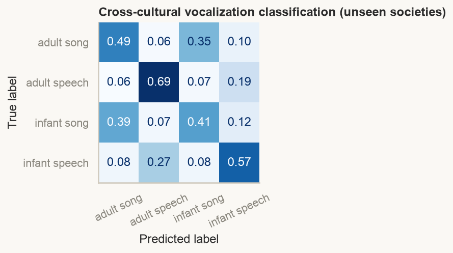

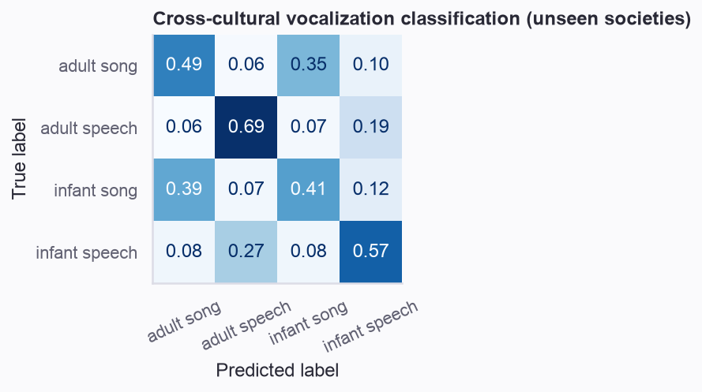

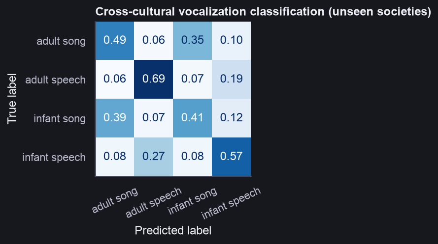

```python
# Draw the results computed above; this cell does not fit the model.
fig, ax = plt.subplots(figsize=(4.6, 3.6))
ConfusionMatrixDisplay.from_predictions(vocalizations["category"], predicted_contexts, normalize="true", cmap="Blues",
                                        colorbar=False, values_format=".2f", ax=ax, xticks_rotation=25)
ax.set_title("Cross-cultural vocalization classification (unseen societies)")
ax.grid(False)
plt.tight_layout()
```

The four-context example centers recordings using all available contexts from each vocalist, including held-out vocalists. This is a batch, within-vocalist discrimination task; it does not estimate performance for a single unaccompanied recording from a new vocalist. Uniform-guess references assume equally likely classes; inspect class frequencies before treating them as empirical baselines.

**Medicine: Biopsies & Chest X-rays**

The Wisconsin breast cancer dataset describes cell nuclei in 569 fine-needle biopsies with 30 measurements (size, texture, smoothness, concavity). Here we evaluate a standardized logistic regression classifier across 5 stratified folds:

```python
from sklearn.datasets import load_breast_cancer

cancer = load_breast_cancer(as_frame=True)
biopsy_features, biopsy_labels = cancer.data, cancer.target            # 0 = malignant, 1 = benign
```

Standardize the measurements within each training fold, fit logistic regression, and evaluate it on the held-out biopsies. Stratified folds preserve approximately the same proportions of benign and malignant examples.

```python
clf = make_pipeline(StandardScaler(), LogisticRegression(max_iter=1000))
cv = StratifiedKFold(5, shuffle=True, random_state=0)
biopsy_scores = cross_val_score(clf, biopsy_features, biopsy_labels, cv=cv)
print(f"accuracy across 5 folds: {biopsy_scores.mean():.1%} (range {biopsy_scores.min():.1%} to {biopsy_scores.max():.1%})")
```

```
accuracy across 5 folds: 97.9% (range 95.6% to 100.0%)
```

Collect held-out predictions to see which diagnoses are confused, and print precision (how often a predicted label is right), recall (how many actual cases are found), and their combined F1 score.

```python
predicted_biopsy_labels = cross_val_predict(clf, biopsy_features, biopsy_labels, cv=cv)
print(classification_report(biopsy_labels, predicted_biopsy_labels, target_names=cancer.target_names, digits=3))
```

```
              precision    recall  f1-score   support

   malignant      0.985     0.958     0.971       212
      benign      0.975     0.992     0.983       357

    accuracy                          0.979       569
   macro avg      0.980     0.975     0.977       569
weighted avg      0.979     0.979     0.979       569
```

**Show the figure code**

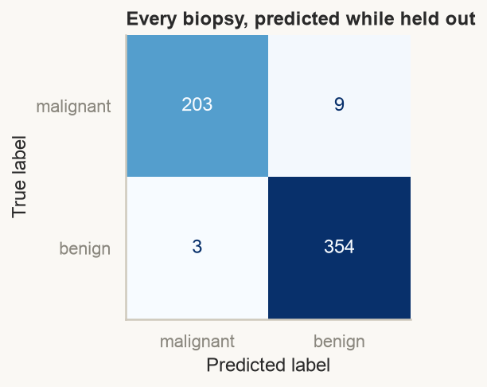

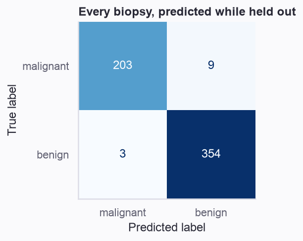

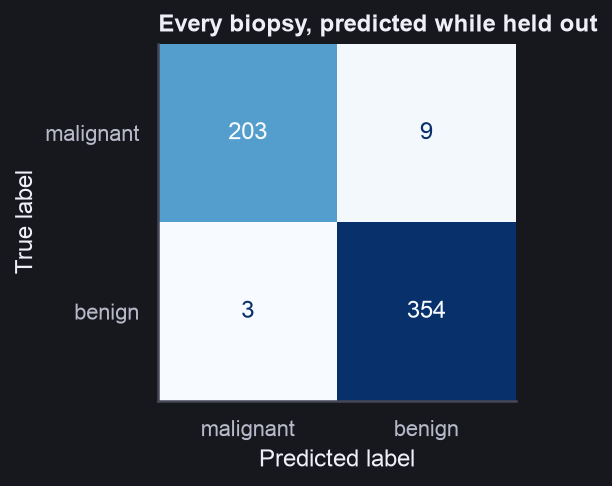

```python
# Draw the results computed above; this cell does not fit the model.
fig, ax = plt.subplots(figsize=(3.8, 3.2))
ConfusionMatrixDisplay.from_predictions(biopsy_labels, predicted_biopsy_labels, display_labels=cancer.target_names, cmap="Blues",
                                        colorbar=False, ax=ax)
ax.set_title("Every biopsy, predicted while held out")
ax.grid(False)
plt.show()
```

The held-out scores and class-specific report above describe this dataset and split. Class imbalance makes majority-class and balanced-accuracy baselines useful comparisons. Clinical use additionally requires external validation and a decision threshold chosen for the consequences of false negatives and false positives; this example does not establish clinical readiness.

**Deep Cut Sneak Peek: Chest X-rays.** [MedMNIST](https://medmnist.com) packages pediatric chest X-rays as $28 \times 28$ grayscale arrays (`PneumoniaMNIST`). Flattening each image into $784$ pixel intensities allows logistic regression to fit a linear template directly on raw pixels:

**Variables in This Example**

`training_pixels` and `test_pixels` have one row per X-ray and one column per pixel. Dividing by 255 maps image brightness to 0–1. The matching diagnosis arrays contain 0 for normal and 1 for pneumonia.

```python
from medmnist import PneumoniaMNIST

training_xrays = PneumoniaMNIST(split="train", download=True, size=28)
test_xrays = PneumoniaMNIST(split="test", download=True, size=28)
# Flatten each image into a row and rescale pixel brightness to 0–1.
training_pixels, training_diagnoses = training_xrays.imgs.reshape(len(training_xrays.imgs), -1) / 255, training_xrays.labels.ravel()
test_pixels, test_diagnoses = test_xrays.imgs.reshape(len(test_xrays.imgs), -1) / 255, test_xrays.labels.ravel()
```

Fit a classifier to the training images and measure its accuracy on the supplied test images. Each pixel acts as a feature; this model has no built-in understanding of neighboring pixels.

```python
pixel_classifier = make_pipeline(StandardScaler(), LogisticRegression(C=0.01, max_iter=2000)).fit(training_pixels, training_diagnoses)
print(f"pneumonia vs normal from raw pixels: {pixel_classifier.score(test_pixels, test_diagnoses):.1%} on {len(test_diagnoses)} test X-rays")
```

```
pneumonia vs normal from raw pixels: 84.9% on 624 test X-rays
```

**Show the figure code**

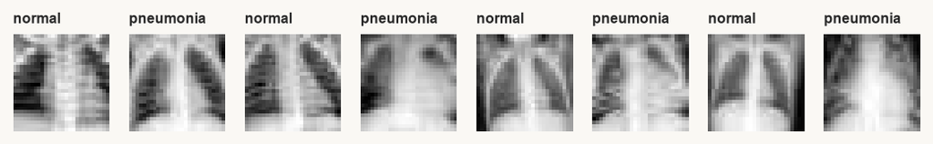

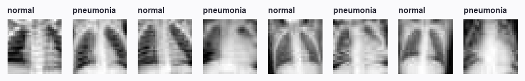

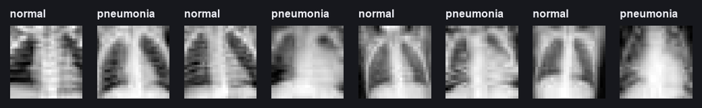

```python
# Draw the results computed above; this cell does not fit the model.
fig, axes = plt.subplots(1, 8, figsize=(9, 1.5))
for k, ax in enumerate(axes):
    i = np.where(test_diagnoses == k % 2)[0][k]
    ax.imshow(test_xrays.imgs[i], cmap="gray"); ax.set_axis_off()
    ax.set_title(["normal", "pneumonia"][k % 2], fontsize=8)
plt.show()
```

A consistent permutation of pixel columns leaves this linear model class unchanged. Convolutional models explicitly exploit local image structure; vision transformers can learn spatial relationships through patch representations and positional information. Neither architecture guarantees translation invariance or clinical generalization.

**Biology: Zebra Finch Calls**

Zebra finches use a structured vocal repertoire: distance calls, chick begging calls, soft contact calls (tet, thuk, tuck), distress calls, and song. [Elie and Theunissen (2016)](https://doi.org/10.1007/s10071-015-0933-6) recorded thousands of vocalizations across dozens of identified birds. Each recording is summarized by 101 acoustic features (mean and standard deviation across 48 mel-frequency bands, spectral centroid, flatness, zero-crossing rate, and duration).

**Variables in This Example**

`call_metadata` records the bird and call type. `call_features` contains 101 sound measurements per recording. `call_spectrograms` displays how frequency content changes over time.

```python
from ml4hl.data import load_finch

finch = load_finch()
call_metadata, call_features, call_spectrograms = finch["meta"], finch["feats"], finch["specs"]
print(f"{len(call_metadata)} calls, {call_metadata.calltype.nunique()} call types, {call_metadata.bird.nunique()} birds")

types = sorted(call_metadata.calltype.unique())
```

```
1600 calls, 10 call types, 42 birds
```

**Show the figure code**

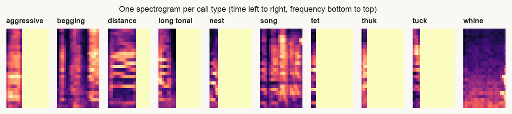

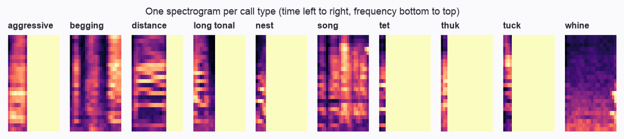

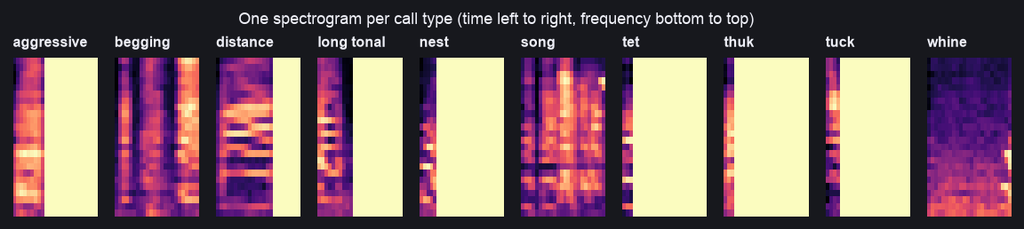

```python
# Draw the results computed above; this cell does not fit the model.
fig, axes = plt.subplots(1, len(types), figsize=(10, 1.6))
for ax, t in zip(axes, types):
    ax.imshow(call_spectrograms[np.where(call_metadata.calltype == t)[0][0]], cmap="magma", aspect="auto")
    ax.set_title(t, fontsize=8); ax.set_axis_off()
fig.suptitle("One spectrogram per call type (time left to right, frequency bottom to top)", y=1.1, fontsize=9)
plt.show()
```

Because each individual bird contributes dozens of recordings, we split folds by bird (`groups=call_metadata.bird`) to test whether the classifier generalizes to **birds it has never heard**:

```python
# Grouping by bird prevents learning an individual bird on the test side.
finch_cv = GroupKFold(5, shuffle=True, random_state=0)
finch_models = {
    "logistic regression": make_pipeline(StandardScaler(), LogisticRegression(max_iter=3000)),
    "gradient boosting": HistGradientBoostingClassifier(max_iter=200, learning_rate=0.1),
}
```

Compare two classifiers using identical folds of held-out birds. This tests whether a call-type pattern carries across individuals.

```python
for name, estimator in finch_models.items():
    s = cross_val_score(estimator, call_features, call_metadata.calltype, groups=call_metadata.bird, cv=finch_cv)
    print(f"{name:>20}: {s.mean():.1%} correct on unseen birds (uniform-guess reference = {1 / len(types):.0%})")
```

```
 logistic regression: 72.2% correct on unseen birds (uniform-guess reference = 10%)
   gradient boosting: 76.1% correct on unseen birds (uniform-guess reference = 10%)
```

Collect held-out call-type predictions for the confusion matrix. Each row will summarize what happened to recordings of one actual call type.

```python
predicted_call_types = cross_val_predict(finch_models["logistic regression"], call_features, call_metadata.calltype,
                           groups=call_metadata.bird, cv=finch_cv)
```

**Show the figure code**

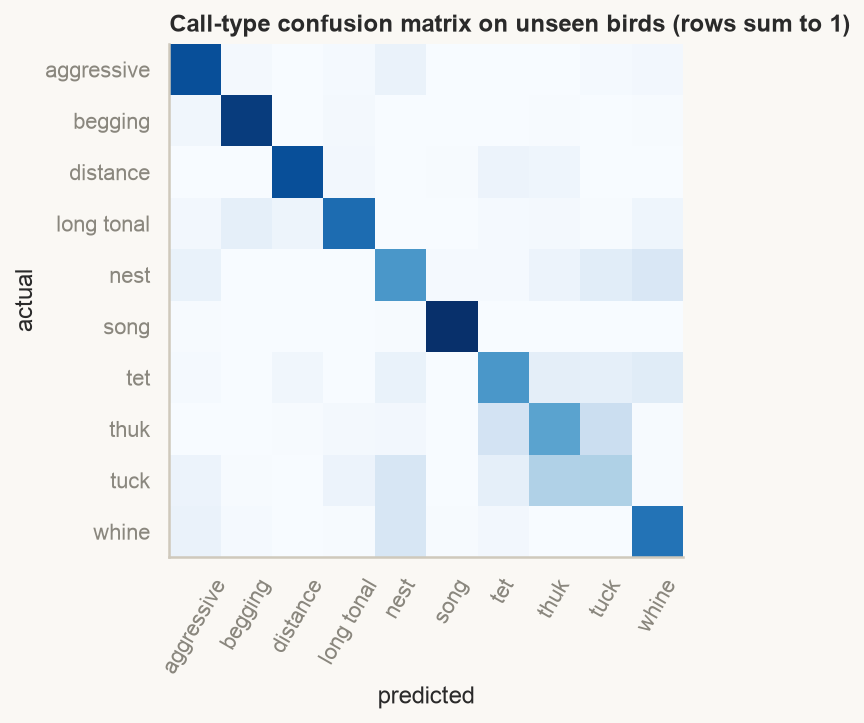

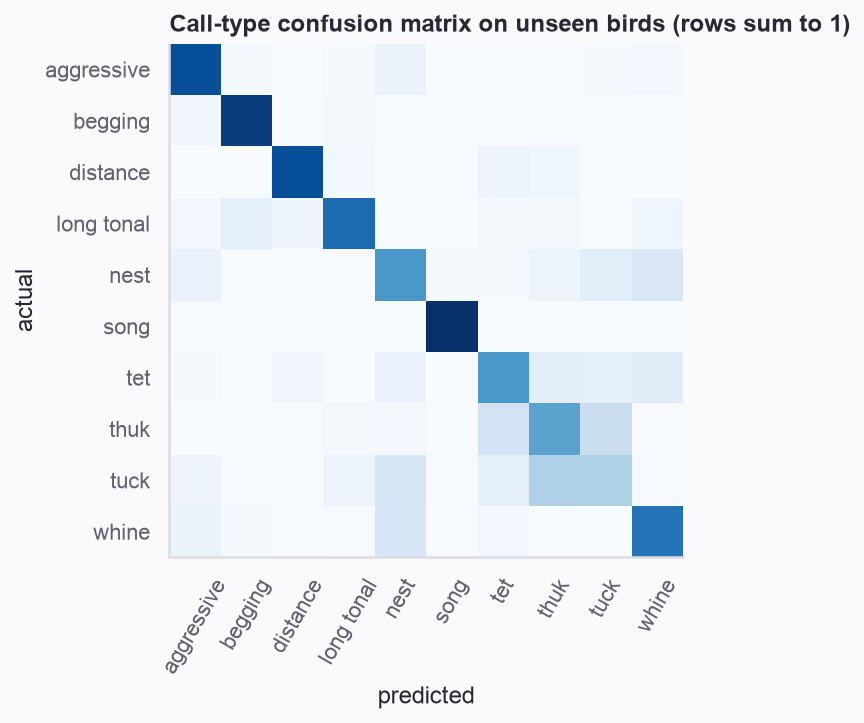

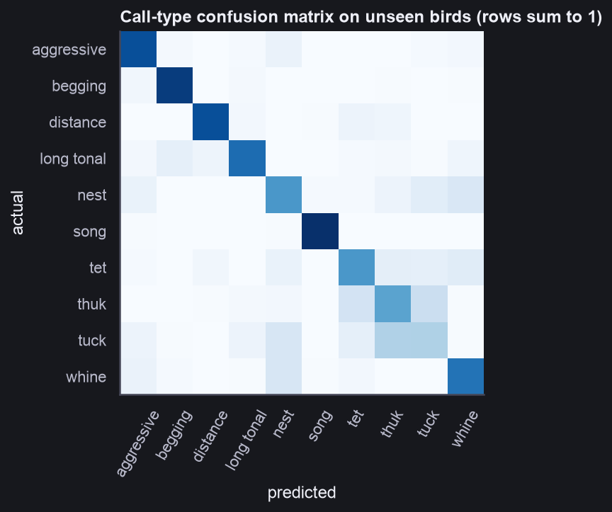

```python
# Draw the results computed above; this cell does not fit the model.
fig, ax = plt.subplots(figsize=(5.4, 4.6))
ConfusionMatrixDisplay.from_predictions(call_metadata.calltype, predicted_call_types, normalize="true", cmap="Blues",
                                        colorbar=False, include_values=False, ax=ax, xticks_rotation=60)
ax.set(title="Call-type confusion matrix on unseen birds (rows sum to 1)", xlabel="predicted", ylabel="actual")
ax.grid(False)
plt.show()
```

**Going faster**

**Gradient boosting** adds small decision trees one after another, with each new tree focused on reducing the errors of the current combined prediction. Implementations such as [XGBoost](https://xgboost.readthedocs.io) (Extreme Gradient Boosting) and [LightGBM](https://lightgbm.readthedocs.io/en/stable/Features.html) (Light Gradient Boosting Machine) can speed up tree training by grouping nearby feature values into bins and processing candidate splits in parallel; they are not faster than every other method on every dataset. Their `fit`/`predict` interface follows the same scikit-learn workflow, and both support graphics processing unit (GPU) training.

# 4 Clustering: Find Groups Nobody Labeled

Every regression and classification example above trained against an explicit target variable: a household expenditure, a clinical diagnosis, or a call type. That paradigm is **supervised** learning. Often, however, a dataset arrives without labels, and the scientific question is whether the observations organize into discrete subpopulations or vary along a continuous spectrum. Do psychiatric symptom questionnaires separate into distinct clinical subtypes? Do musical pieces group into discrete therapeutic moods? **Clustering** addresses this setting as a core method of **unsupervised** learning.

When no external labels are used to score a partition, each clustering algorithm defines a specific geometric criterion for what counts as a group. We examine three foundational criteria below.

## 4.1 Clusters as Connected Ink

A **connectivity-based** criterion defines a cluster as a connected neighborhood of nearby points. Place a disc of radius $\varepsilon$ around every observation; whenever two discs overlap, link their points into the same connected component.

**Show the interactive figure code**

```python
show("percolation")
```

Increase the disc radius slowly from small to large. At tiny radii every observation sits isolated as singleton noise. At intermediate radii, dense neighborhoods coalesce into a small number of components before eventually merging into a single spanning cluster. The inset curve tracks the component count across radii: a wide plateau indicates a range of scales over which the cluster structure remains stable.

Switch the mode toggle to **exemplar voting** to inspect **affinity propagation**, where points exchange messages (packets of information) that reveal their pairwise similarity until a subset of representative **exemplars** (marked with stars) emerges to anchor each cluster. Raising the preference parameter increases the number of selected exemplars.

## 4.2 K-means: Centers That Move

**K-means** divides observations into a number of groups you choose in advance, called $k$. Each group has a center, its **centroid** (the average position of its members). The method tries to bring each point close to its group center by reducing **inertia**, the sum of squared point-to-center distances — another loss, like the squared misses of our regression line. Starting with $k$ center locations, the algorithm alternates two steps until the loss converges (stops changing):

1. **Assignment step**: assign each point to its closest centroid (creating territories around the centers).
2. **Update step**: recompute each centroid as the mean of the points assigned to it.

**Show the interactive figure code**

```python
show("kmeans")
```

Press **step** several times to watch the assignment territories and centroid positions alternate, then press play. Both steps strictly decrease (or leave unchanged) the total squared distance shown in the sparkline, meaning K-means is performing coordinate descent on an error surface. Try **new start** with random initialization several times: two centroids occasionally split a single cloud while leaving two distinct clouds merged — a local minimum of the inertia surface. Switching to **k-means++** spreads initial centroids with probability proportional to squared distance, often improving initialization without guaranteeing the best solution (and serving as `scikit-learn`’s default).

## 4.3 Hierarchical Clustering: A Family Tree of Points

When the number of clusters $k$ is unknown in advance, **agglomerative hierarchical clustering** constructs a nested hierarchy across all scales: start with each point in its own singleton cluster, merge the two closest clusters at each step, and record the merge distances as a binary tree (**dendrogram**).

**Show the interactive figure code**

```python
show("dendrogram")
```

Drag the horizontal dashed cut line up and down: every subtree crossing the cut line forms a cluster. Long vertical branches indicate large distance gaps between merges, marking natural scales at which to partition the tree. Use the **linkage** selector to change how distance between groups is defined: **single linkage** (nearest-pair distance) follows elongated chains, **complete linkage** (farthest-pair distance) favors compact diameters, and **Ward linkage** minimizes within-cluster variance at each merge.

**Takeaway #6**

Clustering partitions data according to a geometric assumption about their proximity or distance (touching neighborhoods, spherical centers, or hierarchical linkage).

## 4.4 Applied Examples

**Psychology: Symptom Profiles**

The [DASS-42](https://openpsychometrics.org/_rawdata/) (42-item Depression Anxiety Stress Scales) inventory measures depression, anxiety, and stress across 42 self-report items ($N \approx 32,000$ respondents after validity screening). Do respondents separate into discrete symptom subtypes, or vary continuously along a severity gradient?

```python
from ml4hl.data import load_dass, dass_items

dass = load_dass()
scales = ["depression", "anxiety", "stress"]
print(f"{len(dass):,} respondents")
dass[scales].describe().round(1)
```

```
32,221 respondents
```

|  | depression | anxiety | stress |
| --- | --- | --- | --- |
| count | 32221.0 | 32221.0 | 32221.0 |
| mean | 20.6 | 15.5 | 20.7 |
| std | 12.2 | 10.0 | 10.4 |
| min | 0.0 | 0.0 | 0.0 |
| 25% | 10.0 | 7.0 | 13.0 |
| 50% | 20.0 | 14.0 | 21.0 |
| 75% | 31.0 | 22.0 | 29.0 |
| max | 42.0 | 42.0 | 42.0 |

**Variables in This Example**

`standardized_symptoms` puts the depression, anxiety, and stress scales on comparable units. A separation (silhouette) score compares how close each respondent is to their own cluster versus other clusters; larger values indicate clearer separation.

```python
from sklearn.cluster import KMeans
from sklearn.metrics import silhouette_score

# Put all three symptom scales on comparable units before measuring distance.
standardized_symptoms = StandardScaler().fit_transform(dass[scales])
sample = rng.choice(len(standardized_symptoms), 4000, replace=False)       # Use 4,000 respondents because comparing all pairs is expensive.
# Try two through seven clusters; assess separation on a fixed respondent subset.
separation_scores = {k: silhouette_score(standardized_symptoms[sample], KMeans(k, n_init=10, random_state=0).fit_predict(standardized_symptoms)[sample])
       for k in range(2, 8)}
```

Fit four groups for an illustrative profile comparison, then average each symptom scale within each group. Ordering these averages by severity makes the patterns easier to compare.

```python
symptom_clusters = KMeans(4, n_init=10, random_state=0).fit(standardized_symptoms)
profiles = dass[scales].groupby(symptom_clusters.labels_).mean()
profiles = profiles.loc[profiles.mean(axis=1).sort_values().index]
```

**Show the figure code**

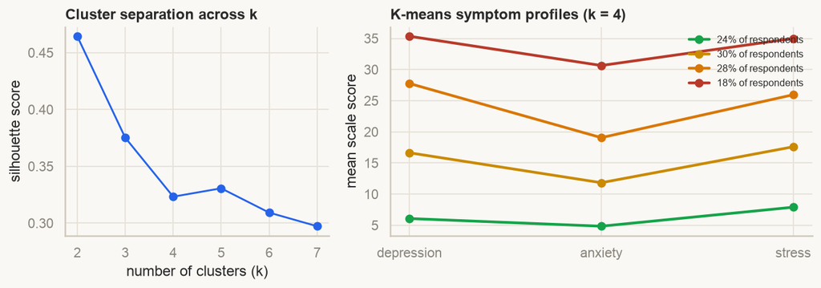

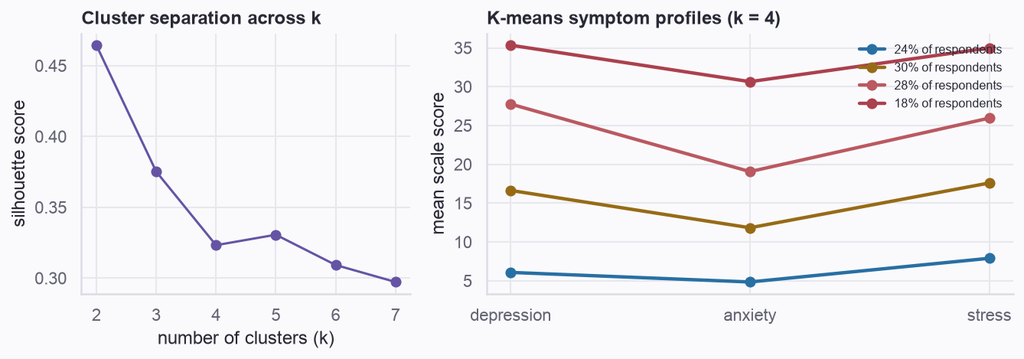

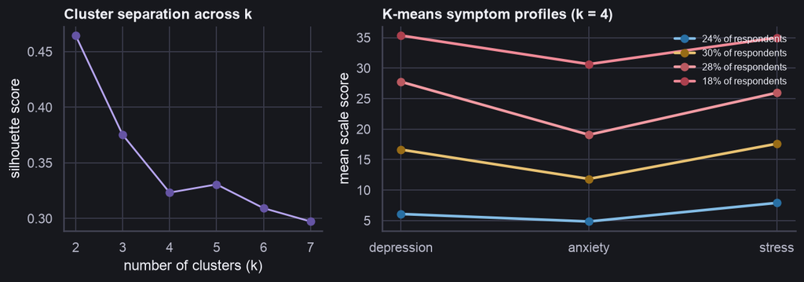

```python
# Draw the results computed above; this cell does not fit the model.
fig, axes = plt.subplots(1, 2, figsize=(9.5, 3.4), gridspec_kw={"width_ratios": [1, 1.6]})
axes[0].plot(list(separation_scores), list(separation_scores.values()), "o-", color=C["blue"])
axes[0].set(xlabel="number of clusters (k)", ylabel="silhouette score", title="Cluster separation across k")
for (cl, row), col in zip(profiles.iterrows(), [C["green"], C["gold"], C["orange"], C["red"]]):
    axes[1].plot(scales, row.values, "o-", color=col, lw=2.2, label=f"{(symptom_clusters.labels_ == cl).mean():.0%} of respondents")
axes[1].set(ylabel="mean scale score", title="K-means symptom profiles (k = 4)")
axes[1].legend(frameon=False, fontsize=8)
plt.tight_layout()
```

Inspect the profile curves and silhouette scores above. Ordered severity profiles can arise when K-means partitions a continuous distribution. A silhouette maximum alone does not establish a true number of psychological subtypes, and these clusters are not validated diagnoses.